# DFTPhaseAmp

## Real-Valued Discrete Fourier Transform (DFT)

```python
import numpy as np
import matplotlib.pyplot as plt
```

We saw that it's possible to detect a particular sinusoid if we check both the sine and the cosine at its frequency. Now we're going to use this observation to devise a mathematical operator known as the *Discrete Fourier Transform (DFT)* which checks over all possible pure sines and cosines that go through an integer number of samples over a particular interval. As it turns out, it's sufficient to check ceil(N/2) such cosines and ceil(N/2) such sines, for N samples. Below is an example where there are $N = 40$ samples, and we have each of 20 sines and cosines

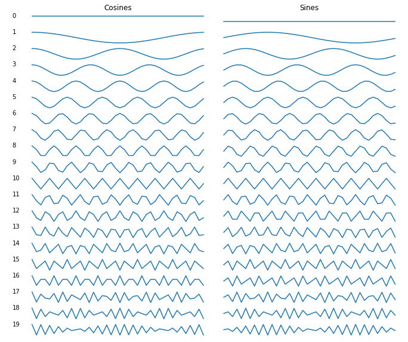

```python
def make_plots(N):
    plt.figure(figsize=(12, 20))
    n_freqs = int(np.ceil(N/2))
    for i in range(n_freqs):
        t = np.linspace(0, 1, N+1)[0:N]
        c = np.cos(2*np.pi*i*t)
        s = np.sin(2*np.pi*i*t)
        plt.subplot2grid((N*10, 21), (i*10, 0), rowspan=10, colspan=1)
        plt.axis('off')
        plt.xlim([-1, 1])
        plt.ylim([-1, 1])
        plt.text(0, 0.5, "{}".format(i))
        plt.subplot2grid((N*10, 21), (i*10, 1), rowspan=10, colspan=10)
        plt.plot(c)
        plt.ylim(-1.5, 1.5)
        plt.axis('off')
        if i == 0:
            plt.title("Cosines")
        plt.subplot2grid((N*10, 21), (i*10, 11), rowspan=10, colspan=10)
        plt.plot(s)
        plt.ylim(-1.5, 1.5)
        plt.axis('off')
        if i == 0:
            plt.title("Sines")
    plt.tight_layout()


def dft(x):
    N = len(x)

make_plots(40)
```

### Real DFT Definition

Now let's define the DFT Given a signal $x$ with $N$ samples

- Cosine parts: Dot product of $x$ with different cosines

### $c[k] = \frac{2}{N} \sum_{n=0}^{N-1} x[n] \cos(2 \pi k \frac{n}{N}), k = 0, 1, ... ceil(N/2)$

- Sine parts: Dot product of $x$ with different sines

### $s[k] = \frac{2}{N} \sum_{n=0}^{N-1} x[n] \sin(2 \pi k \frac{n}{N}), k = 0, 1, ... ceil(N/2)$

Let's translate this into code now. We simply need to loop over ceil(N/2) sines and cosines, and we store the dot products with each in arrays

```python
def get_dft(x):
    """
    Parameters
    ----------
    x: ndarray(N)
        Signal of interest

    Returns
    -------
    c: ndarray(ceil(N/2)), s: ndarray(ceil(N/2))
        Cosine and sine components of the DFT
    """
    N = len(x)
    n_freqs = int(np.ceil(N/2))
    n = np.arange(N)
    c = np.zeros(n_freqs)
    s = np.zeros(n_freqs)
    for k in range(n_freqs):
        c[k] = np.sum(x*np.cos(2*np.pi*k*n/N)) / (N/2)
        s[k] = np.sum(x*np.sin(2*np.pi*k*n/N)) / (N/2)
    return c, s
```

## Amplitude And Phase

Recall that a general sinusoid of amplitude $A$ and phase $\phi$ can be broken down as follows

### $y[n] = A \cos(2 \pi f t + \phi) = A \cos(\phi) \cos(2 \pi f t) - A \sin(\phi) \sin(2 \pi f t) $

### $y[n] = a \cos(2 \pi f t) + b \sin(2 \pi f t)$

For shorthand, define $a$ and $b$ to be as follows

### $a = A \cos(\phi), b = A \sin(\phi)$

### Amplitude

We can recover amplitude as follows:

$a^2 + b^2 = A^2\cos^2(\phi) + A^2\sin^2(\phi) = A^2(\cos^2(\phi) + \sin^2(\phi))$

$a^2 + b^2 = A^2$

Therefore,

$A = \sqrt{a^2 + b^2}$

### Phase

We can recover phase as follows

### $\phi = \tan^{-1} \frac{-b}{a} = \tan^{-1} \frac{-A \sin(\phi)}{A \cos(\phi)} = \tan^{-1} \frac{-\sin(\phi)}{\cos(\phi)} $

```python
#Ex) A = 1, phi = -pi/2
# sin(x) = cos(x - pi/2)
print(np.cos(-np.pi/2), +np.sin(np.pi/2))
```

```
6.123233995736766e-17 1.0
```

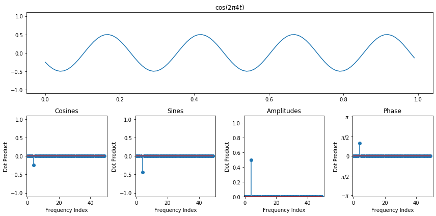

```python
N = 100
f = 4
t = np.arange(N) / N
x = 0.5*np.cos(2*np.pi*f*t + 2*np.pi/3)
c, s = get_dft(x)
amps = np.sqrt(c**2 + s**2)
phases = np.arctan2(-s, c) # Extract phase

plt.figure(figsize=(12, 6))
plot_lim = int(N/2)

plt.clf()
plt.subplot2grid((2, 4), (0, 0), rowspan=1, colspan=4)
plt.plot(t, x)
plt.ylim([-1.1, 1.1])
plt.title("$\cos(2 \pi {} t)$".format(f))
plt.subplot(245)
plt.stem(c, use_line_collection=True)
plt.xlabel("Frequency Index")
plt.ylabel("Dot Product")
plt.title("Cosines")
plt.ylim([-1.1, 1.1])
plt.xlim([-0.5, plot_lim+0.5])
plt.subplot(246)
plt.stem(s, use_line_collection=True)
plt.xlabel("Frequency Index")
plt.ylabel("Dot Product")
plt.title("Sines")
plt.ylim([-1.1, 1.1])
plt.xlim([-0.5, plot_lim+0.5])
plt.subplot(247)
plt.stem(amps, use_line_collection=True)
plt.xlabel("Frequency Index")
plt.ylabel("Dot Product")
plt.title("Amplitudes")
plt.ylim([0, 1.1])
plt.xlim([-0.5, plot_lim+0.5])
plt.subplot(248)
plt.stem(amps*phases, use_line_collection=True)
plt.ylim([-np.pi-0.1, np.pi+0.1])
plt.xlim([-0.5, plot_lim+0.5])
plt.yticks([-np.pi, -np.pi/2, 0, np.pi/2, np.pi], ["$-\\pi$", "$\\pi/2$", "0", "$\\pi/2$", "$\\pi$"])
plt.xlabel("Frequency Index")
plt.ylabel("Dot Product")
plt.title("Phase")
plt.tight_layout()
```

### Time Shifting A Cosine of 2hz

[figure not shown]

Note that a higher frequency has a phase that changes more quickly for the same shifting velocity, because of the following relationship where the frequency distributes through as a factor

### $f(t) = \cos(2 \pi f (t - s)) = \cos(2 \pi f t - 2 \pi f t s))$

### Time Shifting A Cosine of 5hz

[figure not shown]